# 03_report.Rmd

Haitong Xu

# HW08: Statistical Learning

## The Factors Influencing the Activity Level of hOurworld Time Banks

### Overview

Time banks are a form of alternative currency that uses the unit time of labour as the unit of value, allowing their members to make economic exchange within these networks without spending any real currency. [hOurworld](http://www.hourworld.org), similar to the [TimeBanks USA](http://timebanks.org) network introduced in a previous assignment, is a network of time bank initiatives that provide software platform for initiatives to document the exchange being made by their members. The dataset analysed here is a dataset generated by the hOurworld system on August 25th, 2016 during my summer research on time banks. The aim of the research is to construct a typology of time banks that would allow us to understand the organization structure, institutional longevity, the correlation between the two, as well as the organizational advantages and disadvantages of different models of time bank operation.

To identify the key variables that influence the success of time bank initiatives, we first need to have some measure to quantify it. One of the most helpful measures in this aspect would be the amount of time credit exchange being made in the past year (365 days to be precise). Time banks with more exchange in the past year would be more active, and therefore would presumably have a greater socioeconomic impact in their respective communities. For the purpose of analysis, I divide the time banks into three categories based on the amount of exchange being made in the past year. Those that have made 0 exchange are identified as dormant time banks. Those that have less than 400 hours being exchanged are identified as inactive time banks. Those that have more than 400 hours being exchanged are identified as active time banks. All these boundaries are arbitrary, just to serve as a preliminary exploration of this subject matter - the limitation of this will be explored latter.

Three main factors are identied as being potentially important to the success of time bank initiatives: number of total members, number of coordinators and the ratio of members who are actually active. First, a large membership will naturally produce more hours being exchanged. In addition, a large membership could in theory bring a more diverse skill pool, giving people more incentive to utilize the time bank resource. Second, a higher number of admin account would likely to indicate a higher number of coordinators, giving the time bank initiative greater institutional capacity, and therefore greater activity level. Lastly, an low ratio of active members would make the exchange process really frustrating, as people may have a hard time finding the assistance they need. Thus a high ratio of active members would be truly helpful, leadign to a larger amount of hours being exchanged in the past year.

Using a tree model, I found the impact of these three factors on the amount of hours being exchanged in the past year (and the activity level of the time bank in general) is as following:

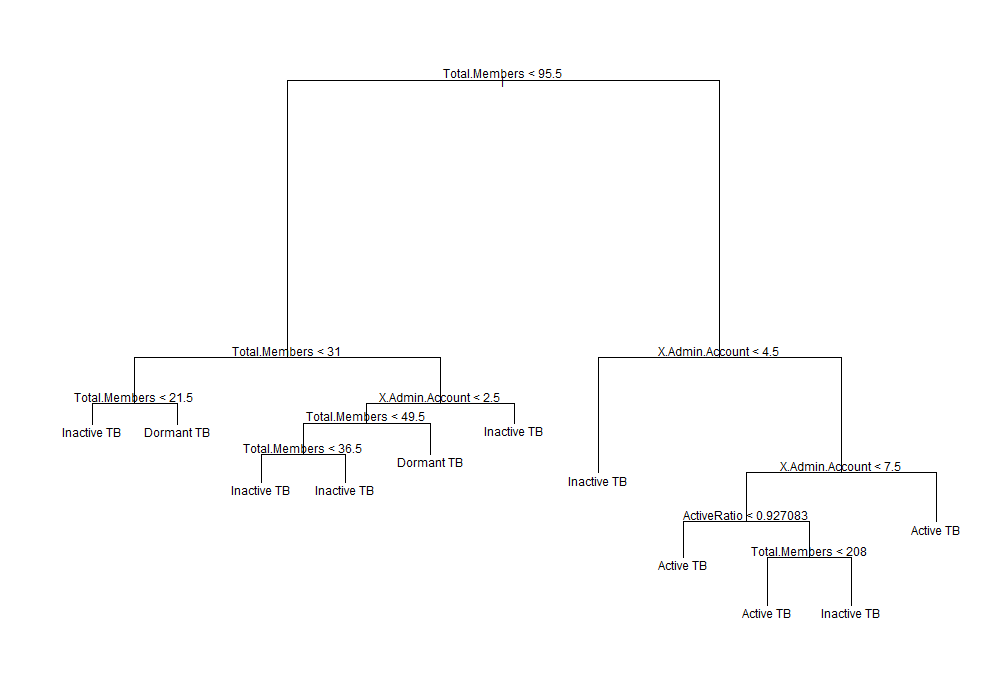

Fig.1: Tree diagram of the relationship between time bank activities and various factors

### Testing the decision tree model

The result is tested using a random forest:

```r
kable(hOurworld_rf$finalModel$confusion)
```

[output not shown]

The mean decrease gini of each variable is as following:

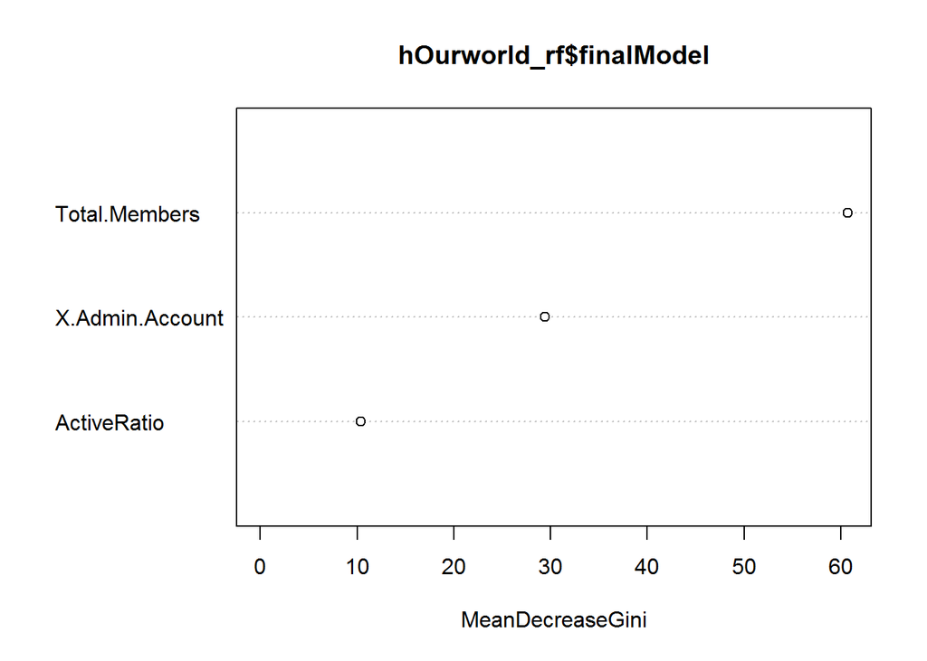

```r
varImpPlot(hOurworld_rf$finalModel)
```

Only the total member size has been proofed to be a strong indicator, which is not really helpful because a larger membership size would inevitably lead to a larger amount of exchange volume. Therefore, this model is not helpful in understanding the relation between the activity level of time banks and the various organizational factors associated with these initiatives..

### Interpretation of the result

So what went wrong. First, the total volume of time credit exchange made in the past year may not be a good indicator of the activity level of time banks as it would be biased towards larger time banks. Instead, this study should utilize other measures, for instance the hours being exchanged per capita in the past year.

Lastly, the number of admin accounts may not be a good indicator of the insitutional capacity of a time bank. Time bank coordinators can be qualitatively differnt in terms of their organizational contribution. On one hand, it is well recognized that many time bank coordinators tend to burn out and go AFK after serving the initiative for some time, but their account may still be there. On the other hand, time banks with full time paid coordinators may not have many coordinator accounts, but the institutional capcity of these initiatives could be marginally higher than time banks with a similar number of admin accounts, but uses volunteer coordinators, due to the greater time commitment and professionalism of the paid coordinators. Therefore, this subject requires further research with a differnt model.